# SVG Tutorial for spatialHeatmap

Jianhai Zhang, PhD student at Genetics, Genomics and Bioinformatics, University of California, Riverside (jzhan067@ucr.edu; zhang.jianhai@hotmail.com) PI: Dr. Thomas Girke, professor at Department of Botany and Plant Sciences, University of California, Riverside (thomas.girke@ucr.edu)

Last update: 27 February, 2020

Maintainer: Jianhai Zhang (jzhan067@ucr.edu; zhang.jianhai@hotmail.com)

# 1 Summary

The R/Bioconductor package spatialHeatmap is designed for intuitive visualisation of configured data matrix and SVG image provided by users. This tutorial is specifically devised for how to make an SVG image and configure it with the data matrix step by step, which is given with *Aribidopsis thaliana* root tissues as an example. For the usage of this package, refer to the [vignette](https://jianhaizhang.github.io/SVG_tutorial_file/vignette.html).

To make a custom SVG image, a png image where regions should have clear contours, a data matrix, the SVG editor [Inkscape](https://inkscape.org/) are required. The image editor [GIMP](https://www.gimp.org/) is optional. Inkscape is used to draw the SVG image with the PNG image as a template, and configure the SVG image with the data matrix. The data matrix is used to colour different regions in the SVG image. GIMP could be used to automatically extract polygons for the SVG image depending on the quality of the PNG template.

To reproduce the results in this tutorial, users can download all the relavant files [here](https://github.com/jianhaizhang/SVG_tutorial_file/tree/master/download) (download an SVG image: hover over the image, right click, and select “Save image as…”; download a PNG image: click the image, click “Download”, right click, and select “Save image as…”; download a TXT file: click the file, click “Raw”, right click, and select “Save as…”.).

# 2 Procedure

## 2.1 Format Gene Expression Matrix

As a convention, the gene expression matrix should be normalised and filtered before downstream processing. The expression matrix (Table 1, Geng et al. (2013)) used in this tutorial is already normalised, so normalisation is not covered. The function `filter_data` (Morgan et al. 2018; Dowle and Srinivasan 2018; R Core Team 2018) is designed to filter expression matrix, which builds on `pOverA` and `cv` in the package “genefilter” (Gentleman et al. 2018).

To use the spatialHeatmap, the data matrix must be formatted in the following way:

1. The row and column names should be gene IDs and sample/conditions respectively.
2. In sample/condition names, a sample name is followed by double underscore “__" then the condition. E.g In “epidermis__140mM_1h" shown in Table 1, “epidermis” is the sample and “140mM_1h” is the condition.
3. In the column names of sample/condition, only letters, digits, single underscore, single space, or dots are allowed.
4. The coloumn names must be unique.

Not all samples in the matrix need to be present in the SVG image, vice versa. Only samples common between the SVG image and data matrix are recognised and coloured. Even a dot, space, underscore, uppercase, or lowercase matters.

The expression matrix is stored as an “SummarizedExperiment” object (Morgan et al. 2018).

```r
  library(spatialHeatmap); library(data.table); library(SummarizedExperiment)
  # Creat the "SummarizedExperiment" class.
  ## The expression matrix, where the row and column names should be gene IDs and sample/conditions, respectively.
  data.path <- system.file("extdata/shinyApp/example", "root_expr_row_gen.txt", package = "spatialHeatmap")
  expr <- fread(data.path, sep='\t', header=TRUE, fill=TRUE)
  col.na <- colnames(expr)[-ncol(expr)]; row.na <- as.data.frame(expr[, 1])[, 1]
  expr <- as.matrix(as.data.frame(expr, stringsAsFactors=FALSE)[, -1])
  rownames(expr) <- row.na; colnames(expr) <- col.na
  con.path <- system.file("extdata/shinyApp/example", "root_con.txt", package = "spatialHeatmap")
  ## Condition is a single column data frame.
  con <- read.table(con.path, header=TRUE, row.names=NULL, sep='\t', stringsAsFactors=FALSE)
  ann.path <- system.file("extdata/shinyApp/example", "root_ann.txt", package = "spatialHeatmap")
  ## Gene annotation is a single column data frame.
  ann <- read.table(ann.path, header=TRUE, row.names=1, sep='\t', stringsAsFactors=FALSE)
  ## The expression matrix, gene annotation, and condition are stored in a "SummarizedExperiment" object. Gene annotation and condition are optional.
  expr <- SummarizedExperiment(assays=list(expr=expr), rowData=ann, colData=con)

  # Filter genes. In "pOA", genes with expression value A >= 1 in at least p=0.03 (3%) of all samples are retained; in "CV", genes with coefficient of variance (cv) between 0.1 and 100 are retained.
  exp <- filter_data(data=expr, pOA=c(1, 0.03), CV=c(0.1, 100), dir=NULL)

  # Get the filtered matrix. "filter_data" returns a "SummarizedExperiment" object.
  df <- assay(exp)
```

Table 1. Gene expression matrix. Rows and columns are genes and sample/conditions respectively.

|  | epidermis__standard_1h | epidermis__140mM_1h | epidermis__140mM_3h | epidermis__140mM_8h |
| --- | --- | --- | --- | --- |
| PSAC | 2.944807 | 2.457910 | 2.862155 | 2.313841 |
| NDHG | 4.243482 | 4.072965 | 4.154074 | 4.935179 |
| PETG | 4.830398 | 5.516260 | 5.390418 | 5.372507 |

## 2.2 Make SVG Images

### 2.2.1 Make Blank SVG Images by Drawing

If the contour in the PNG image is not clear, GIMP would generate low-quality SVG images, so in this case one can draw the blank SVG image with Inkscape by using the PNG as a template. Below is an example of drawing only two polygons.

1. Draw polygons

   Open the root PNG image (Mustroph et al. 2009) in Inkscape. The image can be zoomed by press “-” or “+” on the keyboard. Select the “Draw freeahnd lines (F6)” at the left tool bar. Left click once at the first corner of the polygon, move to the second corner and double left click, and so on. Lastly, when drawing the last line click at the first corner to seal the polygon.

   Select “Edit path by nodes (F2)” from the left tool bar. Draw a large rectangle to select the whole sealed polygon and draw another large rectangle to select all nodes.

   Click the “Make selected nodes smooth” in the top tool bar. Drag the edges and handles to make the sealed polygon aligned with the template, then the first polygon is finished.

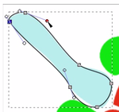

3. Make polygons with shapes

   Alternatively, the polygons can be made with rectangles. Click “Create rectangles and squares (F4)” at the left tool bar and draw a rectangle in the second template polygon. Select the rectangle and click “Object to Path” under the “Path” tab at the top, then the rectangle becomes an SVG path, which can be edited. Switch cursor to “Select and Transform Objects (F1)” and rotate the rectangle as expected.

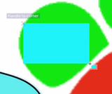

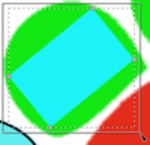

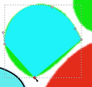

In this root image there are many polygons, so it takes too much time to draw them individually. However, GIMP can be used to extract the polygons automatically.

### 2.2.2 Make Blank SVG Images with GIMP

If the png image contains many polygons and their contours are clear (e.g. the root image), GIMP can be used to automatically extract the polygons.

4. Open the root png image with GIMP. There are five coloured tissues (skyblue, green, red, yellow, blue). The skyblue is not present in the gene matrix while the green, red, yellow, blue correspond to epidermis, cortex, endodermis, stele in the gene matrix respectively. Enable the “Paths” panel under the “Windows” tab at the top. Right click and select “By Color” under “Select”.

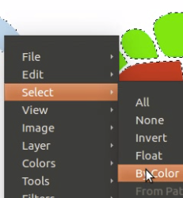

5. Click on the skyblue tissue, then right click, select “To Path” under “Select”, and the paths of all skyblue tissues are extracted in the “Paths” panel.

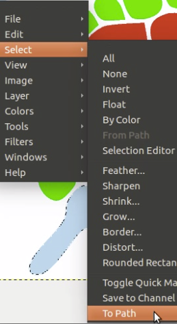

6. Similarly, exrtact paths of other tissues. In the “Paths” panel set paths visible by enabling the eye symbol, then right click and merge visible paths. Right click and export merged paths, which is a blank SVG image.

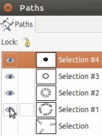

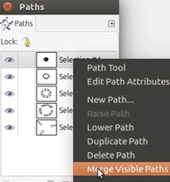

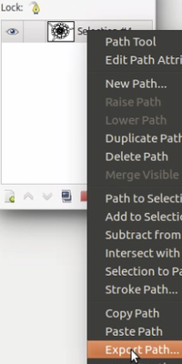

### 2.2.3 Make Blank SVG Images with GIMP and Drawing

7. Place all SVG paths inside a layer/group

   Open the blank fused SVG image in Inkscape (the image can be zoomed by press “-” or “+” on the keyboard). Under the “Layers” tab at the top click “Layers”, the “Layers” panel will come out on the right, then click “+” at the bottom left corner of the panel to add “Layer 1”.

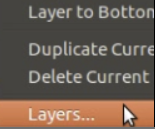

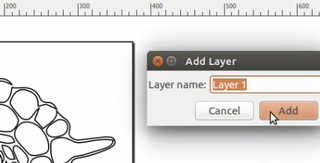

   Draw a rectangle over the fused SVG graph and cut. Then click on “Layer 1” and paste the fused SVG into “Layer 1” (make sure the “Layer 1” is unlocked by refering to the lock symbol). Open the “XML Editor” from the “Edit” tab at the top, if “<svg:path id=”path 77“>” is under “<svg:g id=”layer1" inkscape:label=“Layer 1”>“, then the fused SVG is inside "Layer 1".

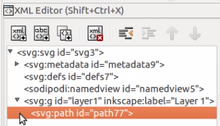

8. Refine and modify the SVG image

   Draw a ractangle over the image, click “Break Apart” under the “Path” tab, then select the outer noisy rectangle by clicking on its edge. Press “delete” on the keyboard to delete it.

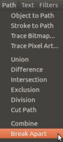

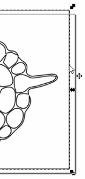

Click the edge of the large fused polygon and move. Use the drawing method to make new polygons (blue) with the fused ones as templates. Delete the fused polygons and move back the new polygons to make the tissue complete.

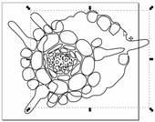

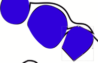

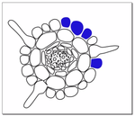

If a large fused polygon needs to be separated, one can use the eraser tool. Drag the fused polygon away from the tissue, select the eraser tool from the left tool bar, then use the eraser to cut the fused polygon into three independent polygons. Select the cut polygons and click “Break Apart” under the “Path” tab at the top, then the three polygons are separated. Place back the three polygons to make the tissue complete.

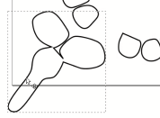

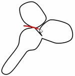

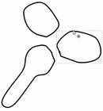

9. Fill and stroke

   Under “Object” tab at the top, select “Fill and Stroke…”, then the “Fill and Stroke (Shift+Ctrl+F)” panel will come out on the right. Select all polygons by drawing a large rectangle over them.

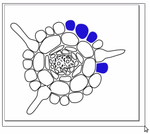

   Under the “Stroke paint” tab in the fill and stroke panel, select “Flat color”. Under the “Stroke style” tab, set the stroke width, e.g.: 1.5 px.

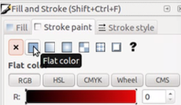

   Under the “Fill” tab, click “No paint” to get a blank SVG image, which is ready to use in next section.

## 2.3 Configure the SVG Image with Gene Matrix

In the SVG image, each polygon has a unique ID. To plot spatial heatmaps, these IDs should be exactly replaced with sample names in the gene matrix. Even a dot, space, underscore, uppercase, or lowercase matters. No matter how the blank SVG image is created, it should be placed inside a layer/group before start the following steps.

10. Group same tissues

    If multiple polygons belong to the same tissue type, they should be grouped together. The example of grouping epidermis is given below. Open “XML Editor…” under the “Edit” tab at the top, then the “XML Editor (Shift+Ctrl+X)” panel comes out on the right. Click all the epidermis polygons while pressing the “Shift” key, right click, and select “Group”. A group should not contain another group.

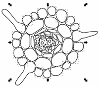

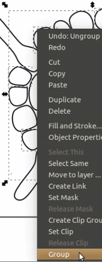

11. Associate polygons with samples

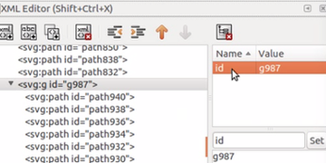

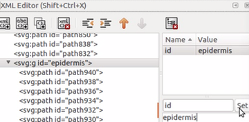

In the “Fill and Stroke (Shift+Ctrl+F)” panel, select “Flat color” under the “Fill” tag, then specify a color for epidermis.

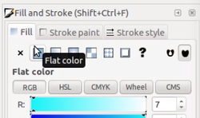

Group other tissues, set ids and colours.

12. Polygon orders

    The polygons are stacked over each other according to their orders in the “XML Editor”, so the first polygon might be invisible because it could be covered by the second, third, and so on. For instance, in the brain SVG image (anatomybodysystem.com 2017; epilepsyresearch 2017), the grey outline polygon (the path “rect5480”) is the first one, and partially covered by other polygons. Therefore, users should drag and organise the paths in expected order.

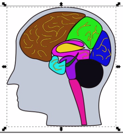

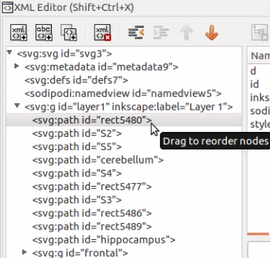